# STEP 3: Download and prepare green reflectance data

## Working with **raster** data

**Raster** data is arranged on a grid – for example a digital photograph.

**Read More**

Learn more about raster data at this [Introduction to Raster Data with Python](https://www.earthdatascience.org/courses/use-data-open-source-python/intro-raster-data-python/)

**Try It: Import stored variables and libraries**

For this case study, you will need a library for working with geospatial raster data (`rioxarray`), more advanced libraries for working with data from the internet and files on your computer (`requests`, `zipfile`, `io`, `re`). You will need to add:

1. A library for building interoperable file paths
2. A library to locate files using a pattern with wildcards

### Download raster data

**Try It: Download sample data**

1. Define a descriptive variable with the sample data url: https://github.com/cu-esiil-edu/esiil-learning-portal/releases/download/data-release/redlining-foundations-data.zip
2. Define a descriptive variable with the path you want to store the sample raster data.
3. Use a conditional to make sure you only download the data once!
4. Check that you successfully downloaded some `.tif` files.

### Working with multispectral data

The data you just downloaded is **multispectral** raster data. When you take a color photograph, your camera actually takes three images that get combined – a red, a green, and a blue image (or band, or channel). Multispectral data is a little like that, except that it also often contains spectral bands from outside the range human eyes can see. In this case, you should have a Near-Infrared (NIR) band as well as the red, green, and blue.

This multispectral data is part of the [Harmonized Landsat Sentinel 30m dataset](https://lpdaac.usgs.gov/products/hlsl30v002/) (HLSL30), which is a combination of data taken by the NASA Landsat missions and the European Space Agency (ESA) Sentinel-2 mission. Both missions collect multispectral data, and combining them gives us more frequent images, usually every 2-3 days. Because they are harmonized with Landsat satellites, they are also comparable with Landsat data from previous missions, which go back to the 1980s.

**Read More**

Learn more about multispectral data in this [Introduction to Multispectral Remote Sensing Data](https://www.earthdatascience.org/courses/use-data-open-source-python/multispectral-remote-sensing/intro-multispectral-data/)

For now, we’ll work with the green layer to get some practice opening up raster data.

**Try It: Find the green layer file**

One of the files you downloaded should contain the **green** band. To open it up:

1. Check out the [HLSL30 User Guide](https://lpdaac.usgs.gov/documents/1698/HLS_User_Guide_V2.pdf) to determine which band is the green one. The band number will be in the file name as `Bxx` where `xx` is the two-digit band number.
2. Write some code to **reproducibly** locate that file on any system. Make sure that you get the **path**, not a **list** containing the path.
3. Run the starter code, which opens up the green layer.
4. Notice that the values range from 0 to about 2500. Reflectance values should range from 0 to 1, but they are **scaled** in most files so that they can be represented as 16-bit integers instead of 64-bit float values. This makes the file size 4x smaller without any loss of accuracy! To make sure that the data are scaled correctly in Python, go ahead and add the `mask_and_scale=True` parameter to the `rxr.open_rasterio` function. Now your values should run between 0 and about .25. `mask_and_scale=True` also represents nodata or na values correctly as nan rather than, in this case -9999. However, this image has been cropped so there are no nodata values in it.
5. Notice that this array also has 3 **dimensions**: `band`, `y`, and `x`. You can see the dimensions in parentheses just to the right of `xarray.DataArray` in the displayed version of the `DataArray`. Sometimes we do have arrays with different bands, for example if different multispectral bands are contained in the same file. However, `band` in this case is not giving us any information; it’s an artifact of how Python interacts with the `geoTIFF` file format. Drop it as a dimension by using the `.squeeze()` method on your `DataArray`. This makes certain concatenation and plotting operations go smoother – you pretty much always want to do this when importing a `DataArray` with `rioxarray`.

```
<xarray.DataArray (y: 447, x: 504)> Size: 901kB
[225288 values with dtype=float32]
Coordinates:
    band         int64 8B 1
  * x            (x) float64 4kB 4.947e+05 4.947e+05 ... 5.097e+05 5.097e+05
  * y            (y) float64 4kB 4.4e+06 4.4e+06 4.4e+06 ... 4.387e+06 4.387e+06
    spatial_ref  int64 8B 0
Attributes: (12/33)
    ACCODE:                    Lasrc; Lasrc
    arop_ave_xshift(meters):   0, 0
    arop_ave_yshift(meters):   0, 0
    arop_ncp:                  0, 0
    arop_rmse(meters):         0, 0
    arop_s2_refimg:            NONE
    ...                        ...
    TIRS_SSM_MODEL:            UNKNOWN; UNKNOWN
    TIRS_SSM_POSITION_STATUS:  UNKNOWN; UNKNOWN
    ULX:                       399960
    ULY:                       4400040
    USGS_SOFTWARE:             LPGS_16.3.0
    AREA_OR_POINT:             Area
```

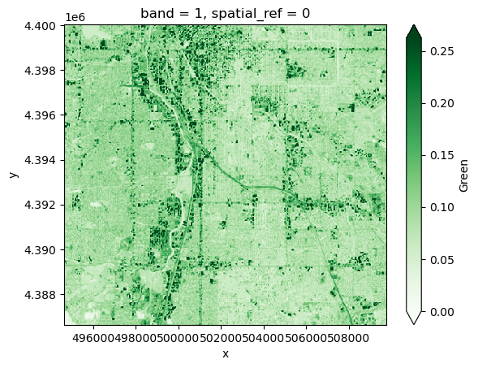

### Cloud mask

In your original image, you may have noticed some splotches on the image. These are clouds, and sometimes you will also see darker areas next to them, which are cloud shadows. Ideally, we don’t want to include either clouds or the shadows in our image! Luckily, our data comes with a cloud mask file, labeled as the `Fmask` band.

**Try It: Take a look at the cloud mask**

1. Locate the `Fmask` file.
2. Load the `Fmask` layer into Python
3. Crop the `Fmask` layer
4. Plot the `Fmask` layer

Notice that your Fmask layer seems to range from 0 to somewhere in the mid-200s. Our cloud mask actually comes as 8-bit **binary** numbers, where each **bit** represents a different category of pixel we might want to mask out.

**Try It: Process the Fmask**

1. Use the sample code below to **unpack** the cloud mask data. Using `bitorder='little'` means that the bit indices will match the Fmask categories in the User Guide, and `axis=-1` creates a new dimension for the bits so that now our array is `x`x`y`x8.
2. Look up the bits to mask in the User Guide. You should mask clouds, adjacent to clouds, and cloud shadow, as well as water (because water may confuse our greenspace analogy)

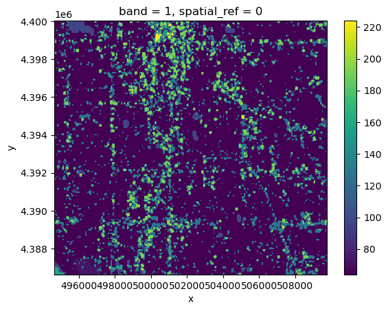

```
array([[ True,  True,  True, ...,  True,  True,  True],
       [ True,  True,  True, ...,  True,  True,  True],
       [ True,  True,  True, ...,  True,  True,  True],
       ...,
       [False, False, False, ...,  True,  True,  True],
       [False, False, False, ...,  True,  True,  True],
       [False, False, False, ...,  True,  True,  True]])
```

**Try It: Apply the cloud mask**

1. Use the `.where()` method to remove all the pixels you identified in the previous step from your green reflectance `DataArray`.

**Try It: Load all bands**

The sample data comes with 15 different bands. Some of these are spectral bands, while others are things like a cloud mask, or the angles from which the image was taken. You only need the spectral bands. Luckily, all the spectral bands have similar file names, so you can use **indices** to extract which band is which from the name:

1. Fill out the `bands` dictionary based on the User Guide. You will use this to replace band numbers from the file name with human-readable names.
2. Locate the position of the band id number in the file path. It is easiest to do this from the end, with negative indices. Fill out the `start_index` and `end_index` variables with the position values. You might need to test this before moving on!
3. Add code to open up the band in the spot to save it to the `band_dict`

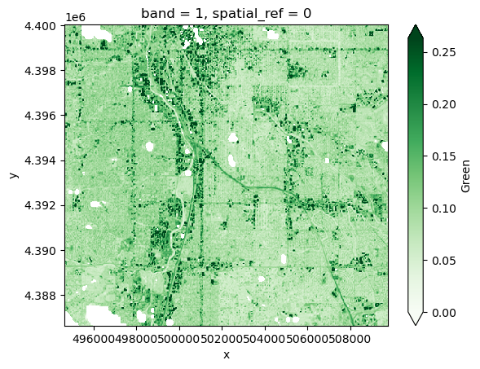

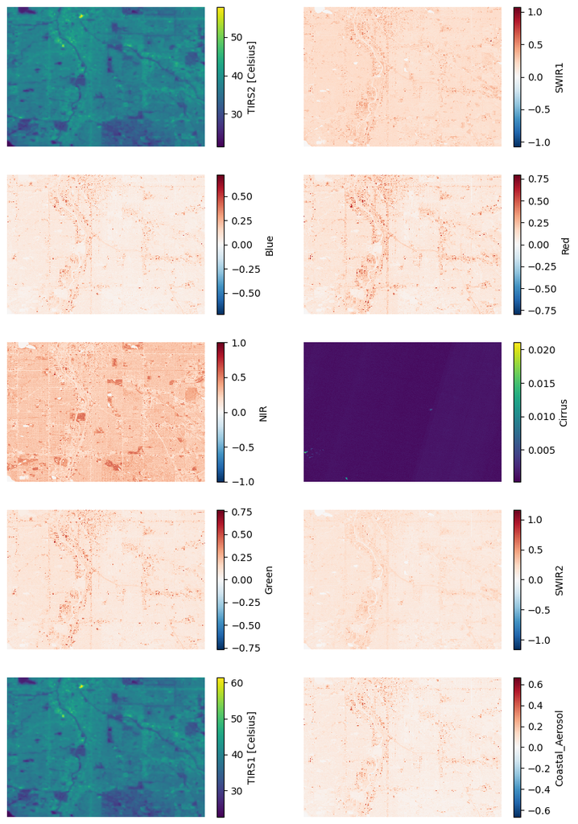

```
Stored 'band_dict' (dict)
```